# Lineare Regression

Jan-Philipp Kolb

20 Juni 2017

# Die lineare Regression

Maindonald - [Data Analysis](https://cran.r-project.org/doc/contrib/usingR.pdf)

- EinfÃ¼hrung in R
- Datenanalyse
- Statistische Modelle
- Inferenzkonzepte
- Regression mit einem PrÃ¤diktor
- Multiple lineare Regression
- Ausweitung des linearen Modells
- …

# Lineare Regression in R - Beispieldatensatz

John H. Maindonald and W. John Braun

DAAG - [Data Analysis and Graphics Data and Functions](http://cran.ms.unimelb.edu.au/web/packages/DAAG/DAAG.pdf)

```r
install.packages("DAAG")
```

```r
library("DAAG")
data(roller)
```

help on roller data:

```r
?roller
```

# Das lineare Regressionsmodell in R

SchÃ¤tzen eines Regressionsmodells:

```r
roller.lm <- lm(depression ~ weight, data = roller)
```

So bekommt man die SchÃ¤tzwerte:

```r
summary(roller.lm)
```

```
##
## Call:
## lm(formula = depression ~ weight, data = roller)
##
## Residuals:
##    Min     1Q Median     3Q    Max
## -8.180 -5.580 -1.346  5.920  8.020
##
## Coefficients:
##             Estimate Std. Error t value Pr(>|t|)
## (Intercept)  -2.0871     4.7543  -0.439  0.67227
## weight        2.6667     0.7002   3.808  0.00518 **
## ---
## Signif. codes:  0 '***' 0.001 '**' 0.01 '*' 0.05 '.' 0.1 ' ' 1
##
## Residual standard error: 6.735 on 8 degrees of freedom
## Multiple R-squared:  0.6445, Adjusted R-squared:  0.6001
## F-statistic:  14.5 on 1 and 8 DF,  p-value: 0.005175
```

Falls das Modell ohne Intercept gesch?tzt werden soll:

```r
lm(depression ~ -1 + weight, data = roller)
```

```
##
## Call:
## lm(formula = depression ~ -1 + weight, data = roller)
##
## Coefficients:
## weight
##  2.392
```

# Summary des Modells

```r
summary(roller.lm)
```

```
##
## Call:
## lm(formula = depression ~ weight, data = roller)
##
## Residuals:
##    Min     1Q Median     3Q    Max
## -8.180 -5.580 -1.346  5.920  8.020
##
## Coefficients:
##             Estimate Std. Error t value Pr(>|t|)
## (Intercept)  -2.0871     4.7543  -0.439  0.67227
## weight        2.6667     0.7002   3.808  0.00518 **
## ---
## Signif. codes:  0 '***' 0.001 '**' 0.01 '*' 0.05 '.' 0.1 ' ' 1
##
## Residual standard error: 6.735 on 8 degrees of freedom
## Multiple R-squared:  0.6445, Adjusted R-squared:  0.6001
## F-statistic:  14.5 on 1 and 8 DF,  p-value: 0.005175
```

# R arbeitet mit Objekten

- `roller.lm` ist nun ein spezielles Regressions-Objekt
- Auf dieses Objekt kÃ¶nnen nun verschiedene Funktionen angewendet werden

```r
predict(roller.lm) # Vorhersage
```

```
##         1         2         3         4         5         6         7
##  2.979669  6.179765  6.713114 10.713233 12.046606 14.180002 14.980026
##         8         9        10
## 18.180121 24.046962 30.980502
```

```r
resid(roller.lm) # Residuen
```

```
##          1          2          3          4          5          6
## -0.9796695 -5.1797646 -1.7131138 -5.7132327  7.9533944  5.8199976
##          7          8          9         10
##  8.0199738 -8.1801213  5.9530377 -5.9805017
```

# Residuenplot

- Sind Annahmen des linearen Regressionsmodells verletzt?
- Dies ist der Fall, wenn ein Muster abweichend von einer Linie zu erkennen ist.
- Hier ist der Datensatz sehr klein

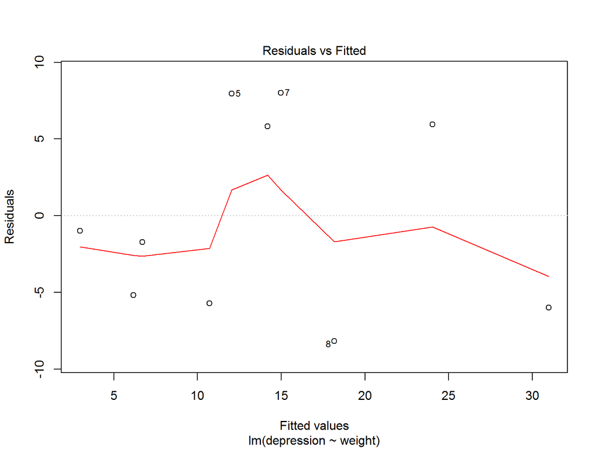

```r
plot(roller.lm,1)
```

# Residuenplot

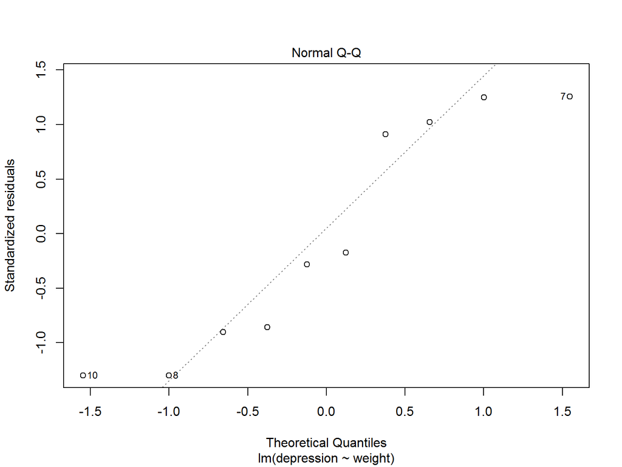

```r
plot(roller.lm,2)
```

- Wenn die Residuen normalverteilt sind sollten sie auf einer Linie liegen.

# Regressionsdiagnostik mit Basis-R

Ein einfaches Modell

```r
N <- 5
x1 <- rnorm(N)
y <- runif(N)
```

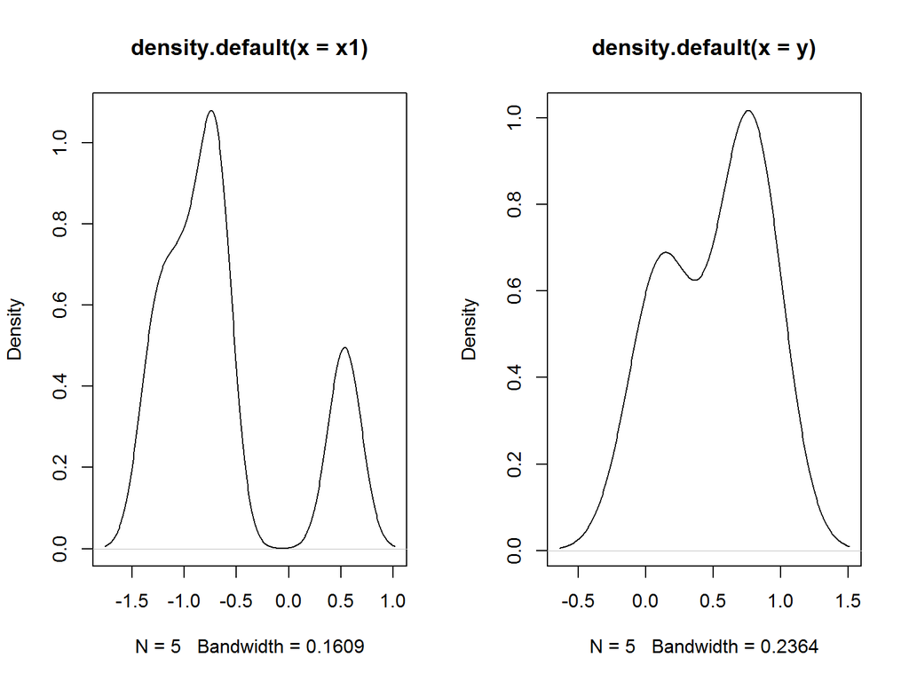

```r
par(mfrow=c(1,2))
plot(density(x1))
plot(density(y))
```

# Modellvorhersage machen

```r
mod1 <- lm(y~x1)
pre <- predict(mod1)
y
```

```
## [1] 0.1643037 0.7959959 0.7198548 0.8014908 0.0683154
```

```r
pre
```

```
##          1          2          3          4          5
## 0.54865911 0.77307435 0.52985319 0.66394953 0.03442433
```

# Regressionsdiagnostik mit Basis-R

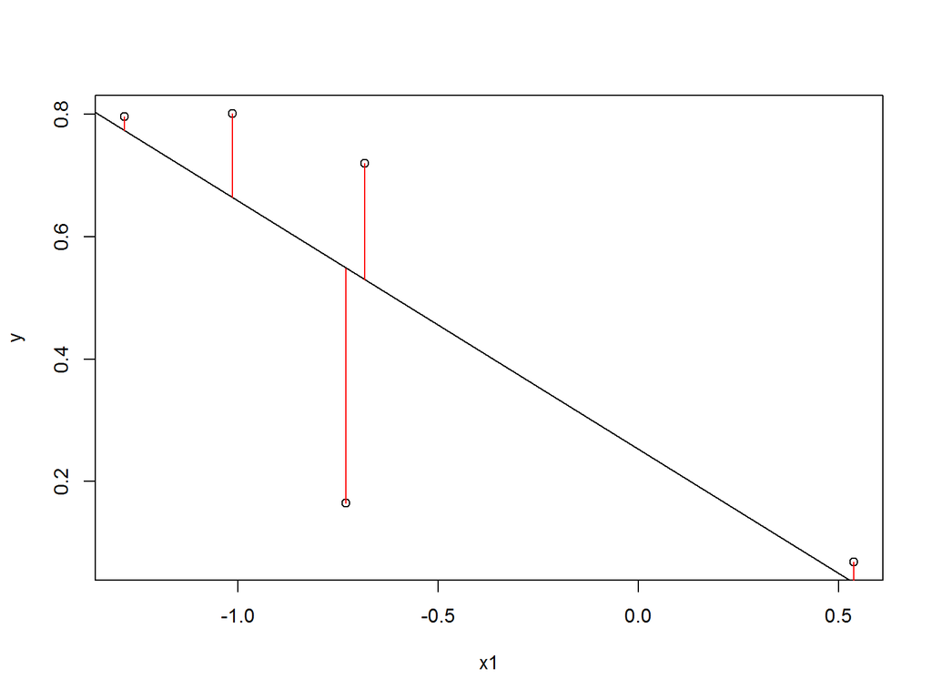

```r
plot(x1,y)
abline(mod1)
segments(x1, y, x1, pre, col="red")
```

# Beispieldaten LuftqualitÃ¤t

```r
library(datasets)
?airquality
```

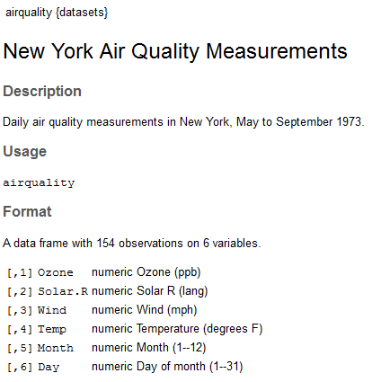

# Das `visreg`-Paket

Ein Modell wird auf dem airquality Datensatz geschÃ¤tzt

```r
install.packages("visreg")
```

```r
library(visreg)
fit <- lm(Ozone ~ Solar.R + Wind + Temp, data = airquality)
summary(fit)
```

```
##
## Call:
## lm(formula = Ozone ~ Solar.R + Wind + Temp, data = airquality)
##
## Residuals:
##     Min      1Q  Median      3Q     Max
## -40.485 -14.219  -3.551  10.097  95.619
##
## Coefficients:
##              Estimate Std. Error t value Pr(>|t|)
## (Intercept) -64.34208   23.05472  -2.791  0.00623 **
## Solar.R       0.05982    0.02319   2.580  0.01124 *
## Wind         -3.33359    0.65441  -5.094 1.52e-06 ***
## Temp          1.65209    0.25353   6.516 2.42e-09 ***
## ---
## Signif. codes:  0 '***' 0.001 '**' 0.01 '*' 0.05 '.' 0.1 ' ' 1
##
## Residual standard error: 21.18 on 107 degrees of freedom
##   (42 observations deleted due to missingness)
## Multiple R-squared:  0.6059, Adjusted R-squared:  0.5948
## F-statistic: 54.83 on 3 and 107 DF,  p-value: < 2.2e-16
```

# Visualisierung

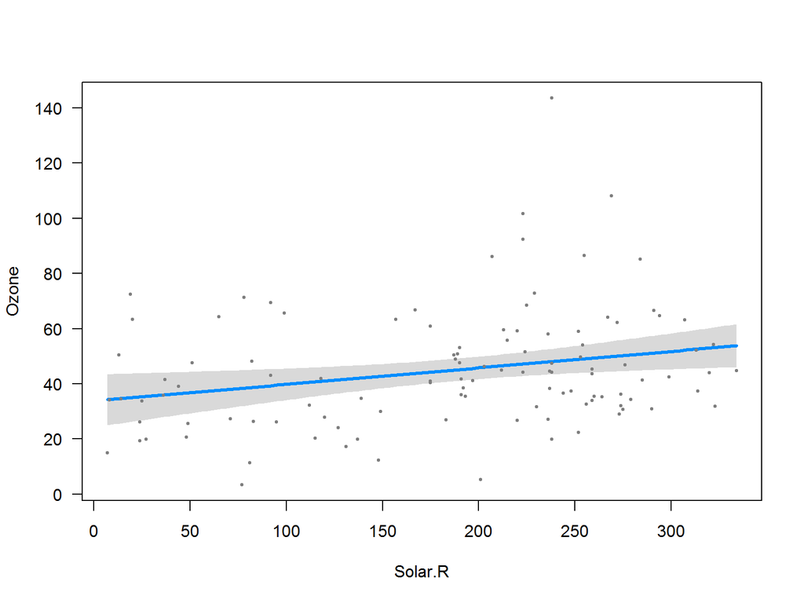

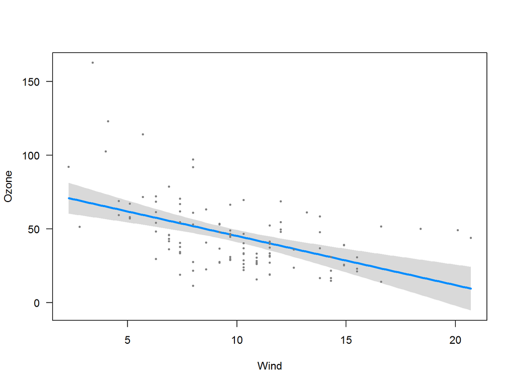

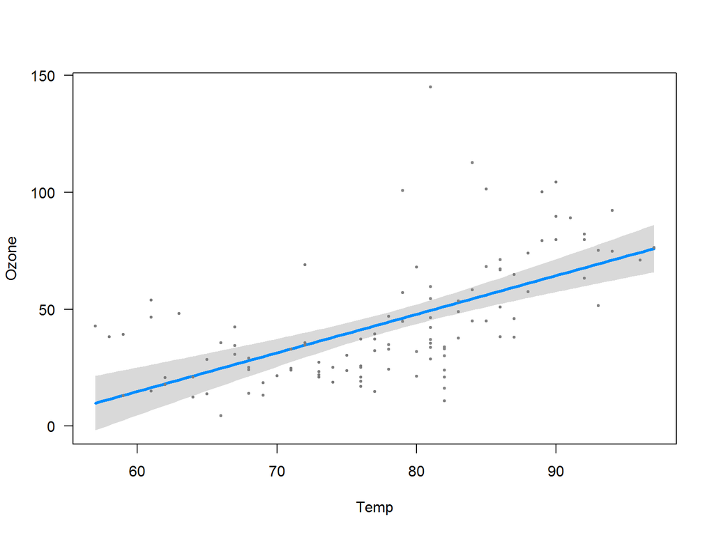

```r
visreg(fit)
```

# [Und dann mit `visreg` visualisiert.](http://myweb.uiowa.edu/pbreheny/publications/visreg.pdf)

- Zweites Argument - Spezifikation erklärende Variable für Visualisierung

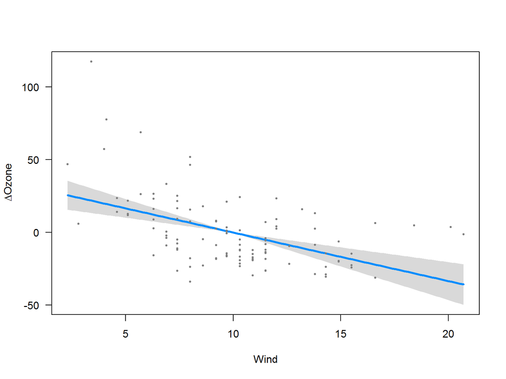

```r
visreg(fit, "Wind", type = "contrast")
```

# Visualisierung mit dem Paket `visreg`

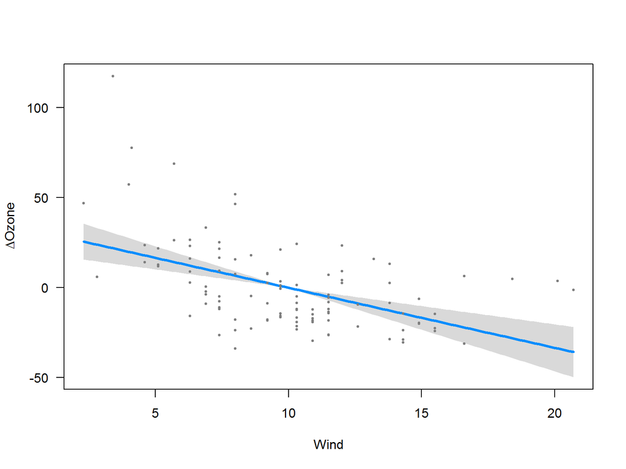

```r
visreg(fit, "Wind", type = "contrast")
```

# Das `visreg`-Paket

- Das Default-Argument fÃ¼r type ist conditional.

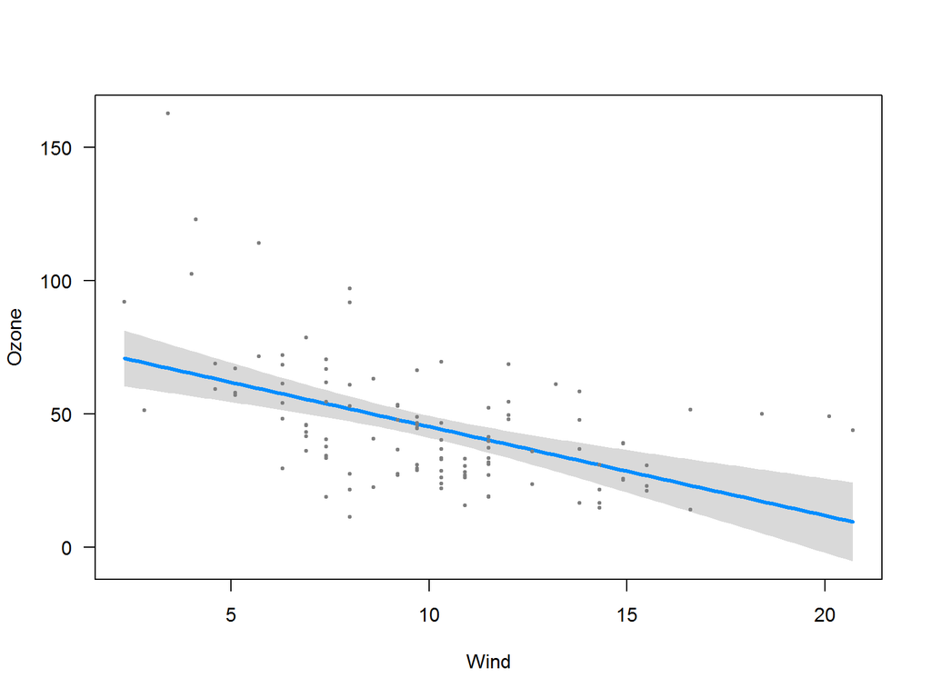

```r
visreg(fit, "Wind", type = "conditional")
```

# Regression mit Faktoren

Mit `visreg` kÃ¶nnen die Effekte bei Faktoren visualisiert werden.

```r
airquality$Heat <- cut(airquality$Temp, 3,
    labels=c("Cool", "Mild", "Hot"))
fit.heat <- lm(Ozone ~ Solar.R + Wind + Heat,
    data = airquality)
summary(fit.heat)
```

```
##
## Call:
## lm(formula = Ozone ~ Solar.R + Wind + Heat, data = airquality)
##
## Residuals:
##     Min      1Q  Median      3Q     Max
## -33.473 -12.794  -2.686   8.461 107.035
##
## Coefficients:
##             Estimate Std. Error t value Pr(>|t|)
## (Intercept) 48.27682    8.83072   5.467 3.07e-07 ***
## Solar.R      0.06524    0.02145   3.042  0.00296 **
## Wind        -3.49803    0.59042  -5.925 3.94e-08 ***
## HeatMild     9.05367    4.88257   1.854  0.06648 .
## HeatHot     43.13970    5.98618   7.207 8.79e-11 ***
## ---
## Signif. codes:  0 '***' 0.001 '**' 0.01 '*' 0.05 '.' 0.1 ' ' 1
##
## Residual standard error: 19.9 on 106 degrees of freedom
##   (42 observations deleted due to missingness)
## Multiple R-squared:  0.6554, Adjusted R-squared:  0.6424
## F-statistic:  50.4 on 4 and 106 DF,  p-value: < 2.2e-16
```

# Effekte von Faktoren

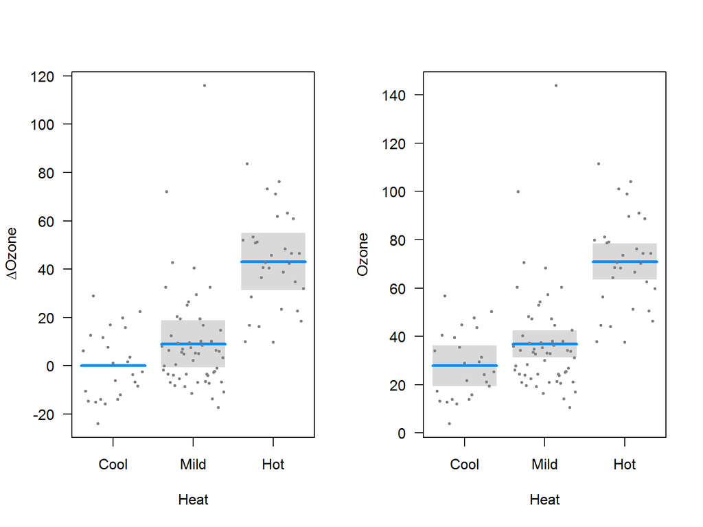

```r
par(mfrow=c(1,2))
visreg(fit.heat, "Heat", type = "contrast")
visreg(fit.heat, "Heat", type = "conditional")
```

# Das Paket visreg - Interaktionen

```r
airquality$Heat <- cut(airquality$Temp, 3,
labels=c("Cool", "Mild", "Hot"))
fit <- lm(Ozone ~ Solar.R + Wind * Heat, data = airquality)
summary(fit)
```

```
##
## Call:
## lm(formula = Ozone ~ Solar.R + Wind * Heat, data = airquality)
##
## Residuals:
##     Min      1Q  Median      3Q     Max
## -34.472 -11.640  -1.919   7.403 102.428
##
## Coefficients:
##               Estimate Std. Error t value Pr(>|t|)
## (Intercept)    4.48042   17.38219   0.258 0.797102
## Solar.R        0.07634    0.02137   3.572 0.000538 ***
## Wind           0.05854    1.34860   0.043 0.965458
## HeatMild      56.72928   18.53110   3.061 0.002805 **
## HeatHot       94.68619   18.61619   5.086 1.63e-06 ***
## Wind:HeatMild -4.11933    1.57108  -2.622 0.010054 *
## Wind:HeatHot  -4.88125    1.74358  -2.800 0.006101 **
## ---
## Signif. codes:  0 '***' 0.001 '**' 0.01 '*' 0.05 '.' 0.1 ' ' 1
##
## Residual standard error: 19.28 on 104 degrees of freedom
##   (42 observations deleted due to missingness)
## Multiple R-squared:  0.6825, Adjusted R-squared:  0.6642
## F-statistic: 37.26 on 6 and 104 DF,  p-value: < 2.2e-16
```

# Steuern der Graphikausgabe mittels `layout`

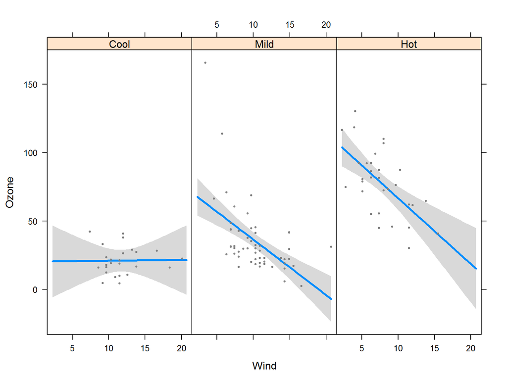

```r
visreg(fit, "Wind", by = "Heat",layout=c(3,1))
```

# Das Paket `visreg` - Interaktionen overlay

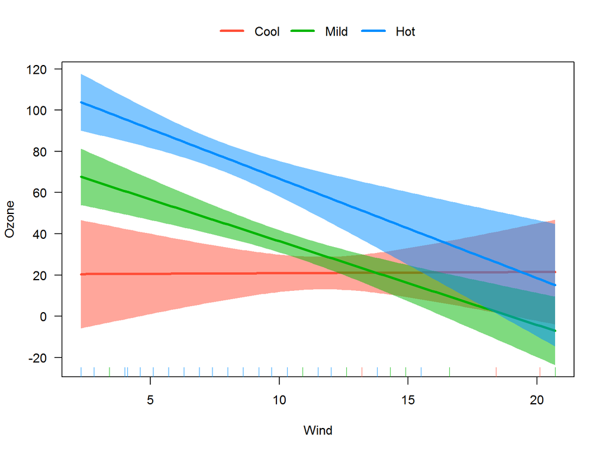

```r
fit <- lm(Ozone ~ Solar.R + Wind * Heat, data = airquality)
visreg(fit, "Wind", by="Heat", overlay=TRUE, partial=FALSE)
```

# Das Paket `visreg` - `visreg2d`

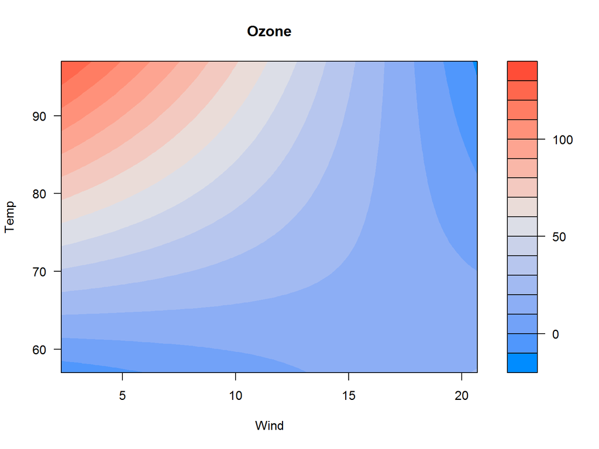

```r
fit2 <- lm(Ozone ~ Solar.R + Wind * Temp, data = airquality)
visreg2d(fit2, "Wind", "Temp", plot.type = "image")
```

# Das Paket visreg - surface

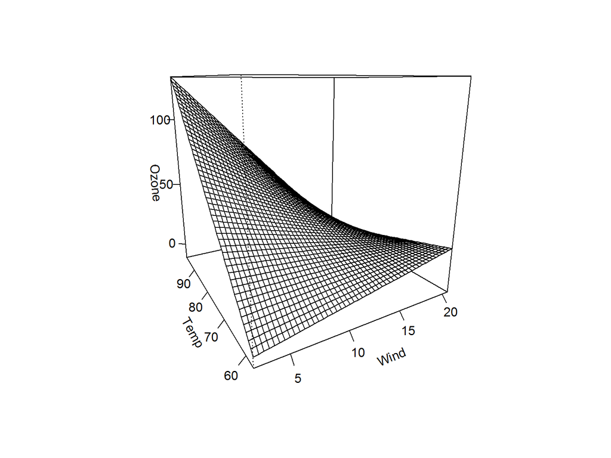

```r
visreg2d(fit2, "Wind", "Temp", plot.type = "persp")
```

# Linkliste - lineare Regression

- Regression - [r-bloggers](http://www.r-bloggers.com/r-tutorial-series-simple-linear-regression/)
- Das Komplette Buch von [Faraway](http://cran.r-project.org/doc/contrib/Faraway-PRA.pdf)- sehr intuitiv geschrieben.
- Gute EinfÃ¼hrung auf [Quick-R](http://www.statmethods.net/stats/regression.html)
- [Multiple Regression](https://www.r-bloggers.com/multiple-regression-part-1/)